# ImageCompression

```python
from sklearn.cluster import MiniBatchKMeans
from scipy.fft import dctn, idctn
from skimage import io

import matplotlib
import matplotlib.pyplot as plt
import numpy as np
import copy
```

## Image Compression

In this notebook, we demonstrate three ways of compressing an image: k-means clustering, the singular value decomposition, and the discrete cosine transform. First, we define an abstract `Compressor` class that can (1) load an image from some specified filepath and (2) render a compressed image together with the original in either grayscale or full color.

```python
class Compressor:
    def __init__(self, filepath):
        self.color_image = io.imread(filepath)[:, :, :3]
        self.gray_image = np.rint(
            (1 / 3) * self.color_image[:, :, 0]
            + (1 / 3) * self.color_image[:, :, 1]
            + (1 / 3) * self.color_image[:, :, 2]
        )

    def renderImage(self, k, compressed, grayscale=False):
        f, ax = plt.subplots(1, 2, figsize=(10, 10))
        if grayscale:
            ax[0].imshow(self.gray_image, cmap="gray")
            ax[1].imshow(compressed, cmap="gray")
        else:
            ax[0].imshow(self.color_image)
            ax[1].imshow(compressed)
        ax[0].set_title("Original Image")
        ax[1].set_title("Compressed (k = " + str(k) + ")")
        plt.show()
```

### K-Means Compression

The `ClusterCompressor` class inherits from the abstract `Compressor` class, and implements a `compress` method that approximates the source image using $k$ colors. Each pixel in the source image contains a red, green, and blue component. Thus, the image can be thought of as a set of 3-dimensional vectors $\{x_1, x_2, ..., x_M\}$, where $M$ is the total number of pixels in the image and $x_i \in \{0,...,255\}^3$ represents the color components of pixel $i$. Running k-means clustering on this set of vectors produces $k$ centroids that represent the "dominant" colors in the image. Each pixel in the compressed image is given the value of its closest centroid. Therefore, the compressed image need only store the index of the centroid closest to each pixel. If there are $k$ centroids, then we require $\lceil\log_2(k)\rceil$ bits per pixel (while an uncompressed image requires 24 bits per pixel). The compression ratio is given as follows.

$$\text{Compression Ratio} = \frac{\lceil{\log_2(k)}\rceil}{24}$$

For example, if we choose 16 unique colors to represent the image, then we require 4 bits per pixel and achieve a 16.67% compression ratio. If we choose 64 unique colors to represent the image, then we require 6 bits per pixel and achieve a 25% compression ratio. Note that these numbers represent an upper bound. Substantial further compression can usually be achieved through run-length encoding because, in the compressed representation, many identical values are close together.

```python
class ClusterCompressor(Compressor):
    def __init__(self, filepath):
        super(ClusterCompressor, self).__init__(filepath)
        self.reshaped_image = self.color_image.reshape(-1, 3)

    def compress(self, k):
        clustering = MiniBatchKMeans(n_clusters=k, random_state=0).fit(
            self.reshaped_image
        )
        centers = clustering.cluster_centers_.astype(np.uint8)
        self.renderImage(
            k,
            centers[clustering.predict(self.reshaped_image)].reshape(
                self.color_image.shape
            ),
        )
```

```python
sample_image = "https://i.imgur.com/meKY6GV.png"
```

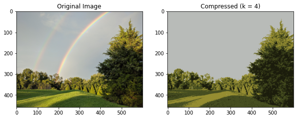

```python
clusterCompressor = ClusterCompressor(sample_image)
clusterCompressor.compress(4)
```

### Low-Rank Compression

The `LowRankCompressor` class inherits from the abstract `Compressor` class, and implements a `compress` method that approximates the source image using its rank $k$ approximation. Here, we work with the grayscale source image for simplicity.

We think of the image as a matrix $I \in \mathbb{R}^{n \times m}$. Let $r \geq k$ denote the rank of $I$, and let $U \in \mathbb{R}^{n \times r}$, $\Sigma \in \mathbb{R}^{r \times r}$, and $V \in \mathbb{R}^{m \times r}$ denote the left-singular-vector orthogonal matrix, singular-value diagonal matrix, and right-singular-vector orthogonal matrix respectively. Then, we can represent the full image exactly as:

$$I = U\Sigma V^T$$

The rank-$k$ approximation to the image is then given by the following, where $A_{1:k}$ denotes the first $k$ columns of the matrix.

$$I = U_{1:k}\Sigma_{1:k} V_{1:k}^T$$

Note that the original image requires us to store a value for every pixel in the image, while the rank-$k$ approximation requires us to only store $k$ different $m$-dimensional vectors, $k$ different n-dimensional vectors, and $k$ scalars. Thus, the compression ratio is given as follows.

$$ \text{Compression Ratio} = \frac{k(m+n+1)}{nm} $$

For example, if we approximate a $600 \times 458$ full-rank image as a rank-$25$ matrix, then we achieve a compression ratio of 9.6%, and if we approximate it as a rank-$100$ matrix, then we achieve a compression ratio of 38.5%.

```python
class LowRankCompressor(Compressor):
    def __init__(self, filepath):
        super(LowRankCompressor, self).__init__(filepath)
        self.u, self.s, self.vh = np.linalg.svd(self.gray_image, full_matrices=False)
        self.rank = np.linalg.matrix_rank(self.gray_image)

    def compress(self, k):
        self.renderImage(
            k, self.u[:, 0:k].dot(np.diag(self.s[0:k])).dot(self.vh[0:k]), True
        )
```

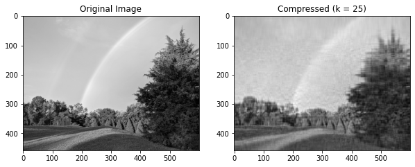

```python
lowRankCompressor = LowRankCompressor(sample_image)
lowRankCompressor.compress(25)
```

### Discrete Cosine Transform Compression

The `SpectralCompressor` class inherits from the abstract `Compressor` class, and implements a `compress` method that approximates the source image using its most dominant $k$ DCT coefficients. Here, once again, we work with the grayscale source image for simplicity.

We think of the image as a matrix $I \in \mathbb{R}^{M \times N}$. Let $D \in \mathbb{R}^{M \times N}$ represent the 2-dimensional discrete cosine transform (DCT) of this image. For $p \in \{1,...,M\}$ and $q \in \{1,...,N\}$, we have:

$$D_{pq} = \alpha_p \alpha_q \sum_{m=0}^{M-1} \sum_{n=0}^{N-1} I_{mn} \cos\left[\frac{\pi(2m+1)p}{2M}\right]cos\left[\frac{\pi(2n+1)q}{2N}\right]$$

Note that, in the above expression, $\alpha_p$ and $\alpha_q$ are as defined below.

$$ \alpha_p = \begin{cases}\sqrt{\frac{1}{M}} & p = 0 \\ \sqrt{\frac{2}{M}} & 1 \leq p < M \end{cases} \quad \quad \quad \alpha_q = \begin{cases}\sqrt{\frac{1}{N}} & q = 0 \\ \sqrt{\frac{2}{N}} & 1 \leq q < N\end{cases} $$

We now select the $k$ entries of $D$ with the highest absolute value (i.e. that contribute the most to the image) and zero-out the remaining entries. We refer to the resulting sparse matrix as $\hat{D}$. Then, the compressed image $\hat{I}$ can be reconstructed from $\hat{D}$ using the following equation, where $\alpha_p$ and $\alpha_q$ are as defined above.

$$\hat{I}_{pq} = \sum_{p=0}^{M-1} \sum_{q=0}^{N-1} \hat{D}_{pq} \left(\alpha_p \alpha_q \cos\left[\frac{\pi(2m+1)p}{2M}\right]cos\left[\frac{\pi(2n+1)q}{2N}\right]\right)$$

Note that the original image requires us to store $nm$ total parameters, while the $k$-component approximation requires us to only store a sparse matrix representation of the DCT. This sparse representation involves storing the coordinates and values of the $k$ most dominant components ($3k$ total parameters). Thus, we have the following compression ratio.

$$ \text{Compression Ratio} = \frac{3k}{nm} $$

For example, if we approximate a $600 \times 458$ image using the 10,000 most dominant DCT components, then we achieve a compression ratio of 10.9%, and if we approximate it using the 20,000 most dominant DCT components, then we achieve a compression ratio of 21.8%.

```python
class SpectralCompressor(Compressor):
    def __init__(self, filepath):
        super(SpectralCompressor, self).__init__(filepath)
        self.transformed = dctn(self.gray_image)

    def compress(self, k):
        indices = np.unravel_index(
            np.abs(self.transformed).flatten().argsort()[-k:][::-1],
            self.gray_image.shape,
        )
        mask = np.ones(self.transformed.shape, bool)
        mask[indices] = False
        compressed = copy.deepcopy(self.transformed)
        compressed[mask] = 0
        self.renderImage(k, idctn(compressed), True)
```

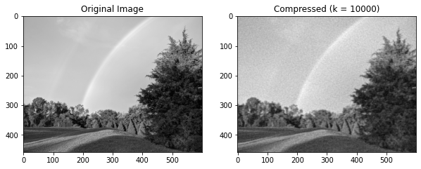

```python
spectralCompressor = SpectralCompressor(sample_image)
spectralCompressor.compress(10000)
```